# DFT & Signal Processing

### **NOTES ON STATISTICS, PROBABILITY and MATHEMATICS**

### Discrete Fourier Transform (DFT):

This is a great [reference](http://www.dspguide.com/ch8/4.htm).

The **fundamental angular frequency** is given by $\frac{2\pi}{N}$, which can be thought of as slicing the $2\pi$ circle into $N$ equal slices.

The frequency of each sinusoid is determined by the parameter $k$. The **frequency parameter**, $k$, is equal to the number of complete cycles that occur over the $N$ points of the signal.

Each point on the left column of the plot below is calculated as $\sin\left(\frac{2\pi}{N}kn\right)$ with $n\in\{0,\dots,5\}$. The first plot is for $k=0$; the second, $k=1$; $k=2$ and, finally, $k=3$. The column on the right is calculated as $\cos\left(\frac{2\pi}{N}kn\right)$.

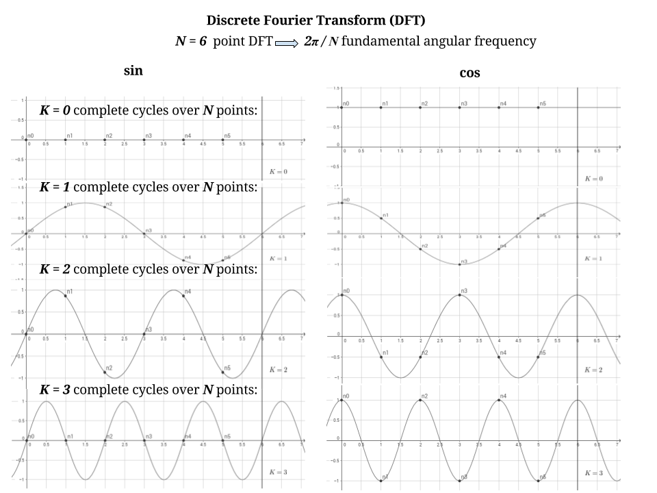

The [DFT is defined](https://www.dsprelated.com/freebooks/mdft/Mathematics_DFT.html) as:

$$X(k)\equiv
\sum_{n=0}^{N-1}\underset{\text{time sequence}}{\underbrace{ x(n)}}\;
\underset{\text{basis
funcs.}}{\underbrace{\exp\left(\color{red}{\mathbf-}i\frac{2\pi}{N}kn\right)}},
\quad k=0,1,\dots,N-1$$

although also found with a [normalizing $1/N$](https://users.cs.cf.ac.uk/Dave.Marshall/Multimedia/node228.html) in front:

$$X(k)\equiv
\frac{1}{N}\sum_{n=0}^{N-1}\underset{\text{time sequence}}{\underbrace{
x(n)}}\; \underset{\text{basis
funcs.}}{\underbrace{\exp\left(\color{red}{\mathbf-}i\frac{2\pi}{N}kn\right)}},
\quad k=0,1,\dots,N-1$$

The minus sign is just a [convention](http://math.stackexchange.com/a/60423/152225) so that the inverse (IDFT) ends up expressed as the sum of positive frequencies:

$$x[n]= \sum_k X(k)
\exp\left(i\,\frac{2\pi}{N} kn\right)$$

which is a sum of sines and cosines if we use the [Euler’s formula](https://en.wikipedia.org/wiki/Euler%27s_formula):

$$e^{ix}=\cos x + i \sin x$$

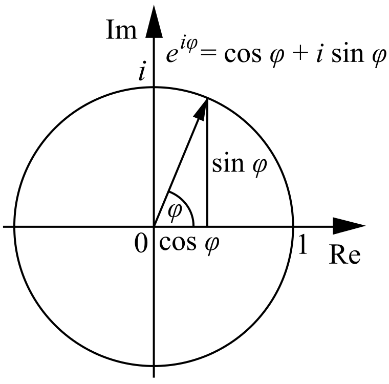

There is another explanation of this convention [here](http://dsp.stackexchange.com/a/19007/27561). The only important part is that the direct and inverse DFT have opposite signs.

We definine $w_N$ - the [**twiddle factor**](http://www.lsi-contest.com/2012/shiyou_3-2e.html):

$$\large w_N \equiv
e^{-i\,\frac{2\pi}{N}}$$

which has periodic properties. The $N$ power of the twiddle factor is:

$$w_N^N=e^{-i\,\frac{2\pi}{N}N}=e^{-i2\pi}=1$$

thanks to Euler’s identity, $e^{i\pi}+1 = 0$, and $e^{-i2\pi}=1$.

And $w_N^{k+N}=w_N^k$ because $w_N^{k+N}=w_N^k\,w_N^N$.

The exponents are $w_N^{kn}=\left(e^{-i\,\frac{2\pi}{N}}\right)^{kn}$.

It makes sense then to express the DFT as a matrix. The $N=4$ (four-point) DFT is especially cool, because splitting the circle into quadrant result in pure sine and cosine waves - in the complex plane, we are either along the $x$-axis (real / cosine), or along the $y$-axis (imaginary /sine). The matrix (really well [explained by Professor Stang](https://youtu.be/M0Sa8fLOajA?t=24m21s)) then simplifies nicely as:

$$W =
\begin{bmatrix}
\omega^0 & \omega^0 &\omega^0 &\omega^0 \\
\omega^0 & \omega^1 &\omega^2 &\omega^3 \\
\omega^0 & \omega^2 &\omega^4 &\omega^6 \\
\omega^0 & \omega^3 &\omega^6 &\omega^9 \\
\end{bmatrix} =
\begin{bmatrix}
1 & 1 & 1 & 1\\
1 & -i & -1 & i\\
1 & -1 & 1 & -1\\
1 & i & -1 & -i\end{bmatrix}$$

where $\omega = e^{-\frac{\pi i}{2}} = -i.$

The DFT would therefore be calculated as:

$$\begin{bmatrix}
X[0]\\X[1]\\X[2]\\X[3]
\end{bmatrix}=
\begin{bmatrix}
\omega^0 & \omega^0 &\omega^0 &\omega^0 \\
\omega^0 & \omega^1 &\omega^2 &\omega^3 \\
\omega^0 & \omega^2 &\omega^4 &\omega^6 \\
\omega^0 & \omega^3 &\omega^6 &\omega^9 \\
\end{bmatrix}
\begin{bmatrix}
x[0]\\x[1]\\x[2]\\x[3]
\end{bmatrix}$$

leading to the [Fast Fourier (FFT)](http://www.lsi-contest.com/2012/shiyou_3-2e.html) expedited method.

There is a great insight found [here](https://www.dsprelated.com/freebooks/mdft/Mathematics_DFT.html):

Defining $s_k(n)\equiv e^{i\,\frac{2\pi}{N}kn}$.

> Finally, we need to understand what the summation over $n$ is doing in the definition of the DFT. We’ll learn that it should be seen as the computation of the inner product of the signals $x$ and $s_k$ defined above, so that we may write the DFT, using inner-product notation, as

$$X(k) \equiv \langle
x,s_k\rangle$$

> where $s_k(n) \equiv e^{j{2\pi n k/N}}$ is the sampled complex sinusoid at (normalized) radian frequency $\omega_k T=2\pi k/N$, where $T$ is the [sampling interval or sampling period](https://www.dsprelated.com/freebooks/mdft/DFT_Definition.html), and the inner product operation $\left<\,\cdot\,,\,\cdot\,\right>$ is defined by $\left<x,y\right> \equiv \displaystyle\sum_{n=0}^{N-1}x(n) \overline{y(n)}$.

This idea of DFT as a measure of similarity between the sampled signal and the sinusoids is very well explained on [this video](https://youtu.be/B2iUDBZzBpY), containing a great example:

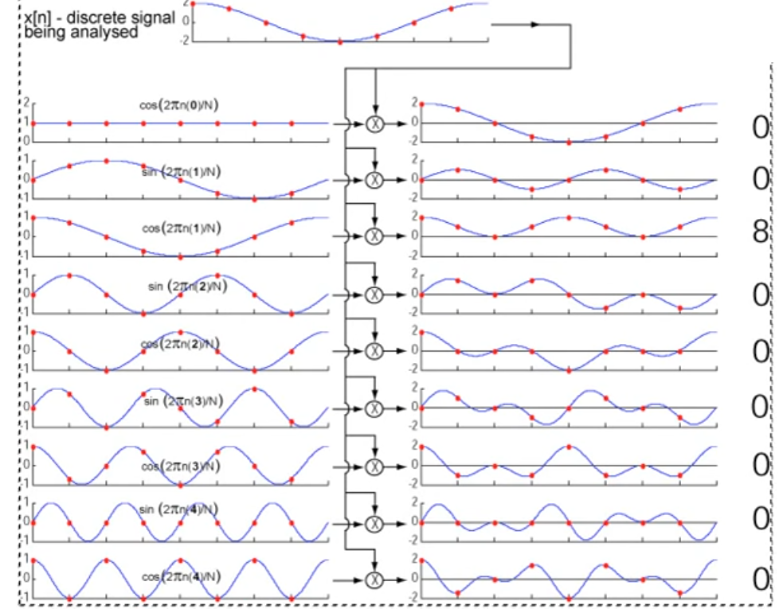

#### 2D DISCRETE FOURIER TRANSFORM:

Now we are going to need two frequency parameters as explained [here](https://youtu.be/nyk75ufbP74) - so instead of $k$, now we have $k$ and $l$.We will also have two indices for the points - so we have not just $n$, but $n$ and $m$:

$$X[k,l]=\frac{1}{MN}\sum_{m=0}^{M-1}\,\sum_{n=0}^{N-1}\,x(m,n)\,\exp\left(-i\,2\pi\left(\frac{km}{M}+\frac{ln}{N}\right)\right)$$

#### MATHLAB to IMAGEJ CORRESPONDENCE:

To be able to understand the output easily, I try to convert this image into a 256 x 256 image, eliminating color information:

```
Im = imread('circ.png');
pkg load image
Im = rgb2gray(Im);
figure, imshow(Im)
```

After this bookkeeping preliminaries I run:

```
A = fft2(double(Im));
```

Here are the plots:

```
subplot(131);
h = imshow(Im);
h2 = get(h,'Parent');
set(h2,'YDir','Normal');
axis equal tight;
title("Circle");

subplot(132);
h = imshow(abs(fftshift(A)),[24 100]);
h2 = get(h,'Parent');
set(h2,'YDir','Normal');
axis equal tight;
title("2D FFT Magnitude");

subplot(133);
h = imshow(angle(fftshift(A)),[-pi pi]);
h2 = get(h,'Parent');
set(h2,'YDir','Normal');
axis equal tight;
title("2D FFT Phase");
```

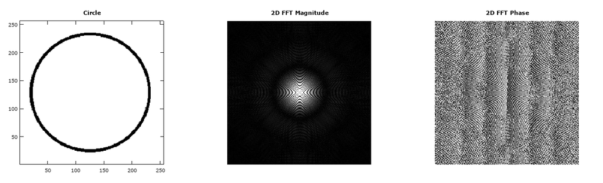

Now I take the same image, and analyze it with ImageJ, checking the output at point `(157, 96)`, like this:

[figure not shown]

So the magnitude is going to be $\sqrt{7.448^2 + 10.458^2} = 12.83.$

The question is, [**How can I get these values out of the `fft2()` output?**](http://stackoverflow.com/a/43196792/4089351)

Here are a few observations which should clarify the scaling used:

So with that in mind, we have:

```
>> Ashifted = fftshift(A);
>> Ashifted(97,158)/255
ans =   7.4484 - 10.4582i
```

Note that by the linearity property of the FFT, you could also divide the input and get the same results:

```
A = fft2(double(Im)/255.0);
>> Ashifted = fftshift(A);
>> Ashifted(97,158)
ans =   7.4484 - 10.4582i
```

[**The next question is how to extract the direction (theta) and frequency (e.g. pixels/cycle)?**](http://stackoverflow.com/a/43197349/4089351)

Let say you have a particular pixel `A(i,j)`, then the direction and frequency in pixels/cycle (as similarly obtained by ImageJ) can be obtained using the following:

```
center = size(A)/2 + 1;
dx = (j-center(2))/size(A,2);
dy = (center(1) - i - 1)/size(A,1);

direction = atan2(dy, dx); %in radians
frequency = 1/sqrt(dx*dx + dy*dy);
```

####EXAMPLE COMPARING MATLAB AND IMAGEJ OUTPUTS:

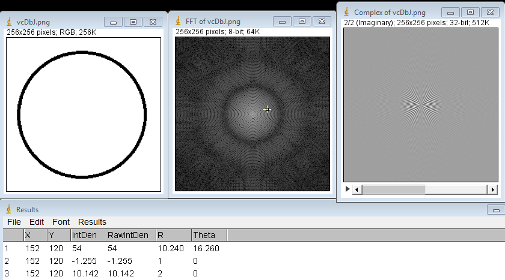

**with ImageJ:**

```
Frequency = 10.24 pixels/cycle (25 cycles)
Theta (direction) = 16.26 degrees
Real part = -1.255
Imaginary part = 10.142
Phase = arctan(10.142 / -1.255) = -82.95 degrees
Magnitude = sqrt(10.142^2 + 1.255^2) = 10.2194
```

and **with Matlab:**

```
Im = imread('circ.png');
pkg load image
Im = rgb2gray(Im);

A = fft2(double(Im) / 255);
Ashifted = fftshift(A);
Ashifted(121,153)

i = 121;
j = 153;

center = size(A) / 2 + 1;
dx = (j - center(2)) / size(A,2);
dy = (center(1) - i - 1) / size(A,1);

direction = (atan2(dy, dx))
dir_degrees = direction * (360 / (2*pi))
frequency = 1 /sqrt(dx*dx + dy*dy)
```

The output:

```
ans =  -1.2553 + 10.1425i
direction =  0.28379
dir_degrees =  16.260
frequency =  10.240
```

[Home Page](http://rinterested.github.io/statistics/index.html)

**NOTE: These are tentative notes on different topics for personal use - expect mistakes and misunderstandings.**